# loanAI - Sovereign Default Prediction

Getting a loan can be good for a country as long as there are means to monitor risk and lower it for successful repayment. However, a default on the loan can be a problem for the country’s credit score and financial future besides causing possible loses for the lender. Even though there are predictive ways to detect if a loan should be a given to a country, the methods to keep track of the risk for a default is still a research field. Considering the number of loans that are given each year, keeping track of the risk for a default is both important for lender’s and country’s benefit. For instance,a sovereign debt crisis faced by Greece in the aftermath of the financial crisis of 2007–08. The country required bailout loans in 2010, 2012, and 2015 from the International Monetary Fund, Eurogroup, and European Central Bank, and negotiated a 50% “haircut” on debt owed to private banks in 2011, which amounted to a €100bn debt relief. The measures that has passed been costly on the life standard of citizens. There were even considerations of exit of Greece from euro zone before the agreements. Being able to predict risk for such defaults is very valuable.

In a well-developed financial system, crisis management is on the downstream and risk prediction is on the upstream. The major purpose of loan risk prediction is to use financial information, such as country’s current data to predict a possible default and take necessary measures to prevent it. The current industry practice tries to asses loan risk before giving the loan and does not keep track of if the risk has changed over time. The lender takes an action on the borrower only after the borrower fails to pay its dept. The action is usually to freeze the borrower’s account and lower the borrower’s credit score. This causes a big problem for the financial future of the borrower. Instead, the lender should take preventative actions by monitoring the risk of a debt failure. This is possible by creating a predictive model by using data mining techniques on the country’s data. This project is purposed to develop such a model for sovereign debt crises prediction.

Besides using CIA’s World Factbook, I am planning to get additional data from the OpenData repositories of countries and banks such as; https://data.worldbank.org/ https://data.europa.eu/euodp/data/ https://www.data.gov/ https://open.canada.ca/en/open-data

In the first plot it can be seen that it is not strighforward to see the sovereign default which happened in 2008 in Greece beforehand by just looking at revenues.

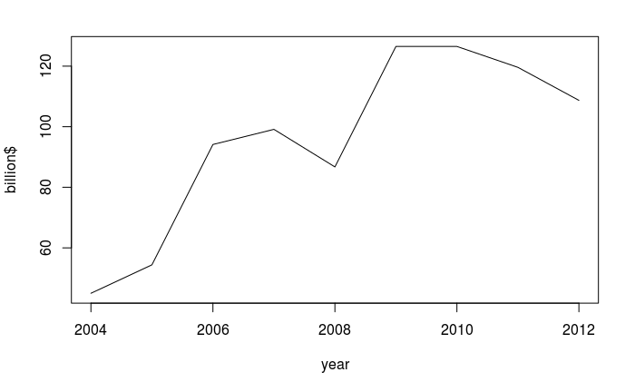

```r
plot1 <- read.csv("/space/DataIncubator/project/loanAI/docs/proposal/plot1.csv")
matplot(plot1[, 1], plot1[, -1], type="l",xlab="year",ylab="billion$")
```

We clearly need to consider other factors such as external debt.

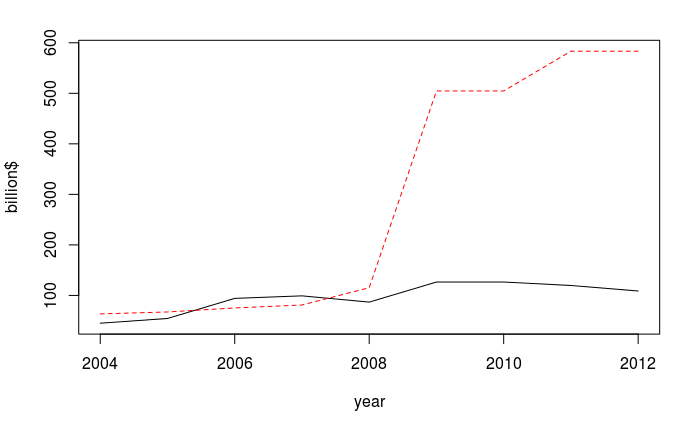

```r
plot2 <- read.csv("/space/DataIncubator/project/loanAI/docs/proposal/plot2.csv")
matplot(plot2[, 1], plot2[, -1], type="l",xlab="year",ylab="billion$")
```

The second plot plot shows Revenues Vs External Debt. It makes it obvious when the sovereign default happened. It is represented by the intersection of the two lines. However to pre-predict, we clearly need more data columns. My project will be discovering the relation of other avaliable data to the sovereign defaults. As result, I am trageting to create a predictive model where I will test on other countries that had sovereign defaults. https://en.wikipedia.org/wiki/List_of_sovereign_debt_crises